```python
# !pip install pyfeats==1.0.1
```

```python
# !pip install -q condacolab
# import condacolab
# condacolab.install()
```

```python
# !mamba install scikit-image
# !mamba install conda-forge::scanpy
```

# Visual Recognition

## Scene Classification Project

1. **Image Description based on BoW**:
   - Build a vocabulary of visual words by clustering local feature vectors from the training set.
   - Use methods like k-means ([sklearn.cluster.KMeans()]), mean-shift ([sklearn.cluster.MeanShift]), or Gaussian Mixtures ([sklearn.mixture.GaussianMixture]) for clustering.
   - Each cluster centroid represents a visual word.
   - Represent each image with a histogram of visual features occurrences based on the vocabulary.
   - Normalize the histogram to maintain consistency across images.
2. **Classification**:
   - Utilize linear classifiers such as support vector machines (SVMs) for multiclass classification.
   - Train N binary 1-vs-all SVMs to classify into N categories.
   - Alternatively, consider using other classifiers like Random Forests.
3. **Assessment**:
   - Measure how well BoW works when paired with a classifier:
     1. Accuracy (sklearn)
     2. Confussion Matrix (sklearn)
1. **Extra Credit**:
   - Experiment with different parameters and design decisions to enhance performance.
   - Analyze the influence of vocabulary size, feature sampling density, window sizes, etc. (10 points)
   - Explore the effect of PCA on image features. (10 points)
   - Compare results between BoVWs obtained from dense features and keypoints. (20 points)
   - Compare difference between using SVM and another classifier. (10 points)
   - Consider combination of 2 features descriptors. (20 points)
   - Compare hard-assignment and soft-assignment (Fisher Vector) methods. (20 points)
2. **Dataset**:
   - https://web.mit.edu/torralba/www/indoor.html
   - Choose 12 categories
   - First 150 images per category, 80 for training, 20 for validation, 50 for testing

```python
import os
import cv2
import numpy as np
import pandas as pd
from sklearn.cluster import KMeans
from skimage import feature
import matplotlib.pyplot as plt

from sklearn.preprocessing import StandardScaler
from skimage.feature import fisher_vector, learn_gmm

from scipy import sparse
import scanpy as sc

import pyfeats

from multiprocessing import Pool
from itertools import chain

np.set_printoptions(linewidth=1000)
num_cores = os.cpu_count()

RANDOM_SEED = 123
```

```python
from google.colab import drive
drive.mount('/content/drive')
```

```python
# access the data
%cd '/content/drive/MyDrive/Colab Notebooks/VR-P2'
```

```
/content/drive/.shortcut-targets-by-id/1tLlbD4Iy0klFYB8NVRI9t2ofBhuupoyf/VR-P2
```

```python
#

list_images = []
list_labels = []

path = f'/content/drive/MyDrive/Colab Notebooks/VR-P2/indoorCVPR_09/Images/'

for folder in os.listdir(path):
  print(folder)
  for filename in os.listdir(os.path.join(path, folder)):
    path_img = os.path.join(path, os.path.join(folder, filename))
    if filename.endswith(".jpg") or filename.endswith(".png"):
        image = cv2.imread(path_img)
        if image is None:
            print('  Image is None: ', filename)
            continue
        else:
            image = cv2.cvtColor(image, cv2.COLOR_BGR2GRAY)
            image = cv2.resize(image, (150, 150), interpolation = cv2.INTER_CUBIC)
            list_images.append(image)
            list_labels.append(folder)
```

```
gameroom
  Image is None:  gameroom_gif.jpg
livingroom
  Image is None:  salon28_gif.jpg
bathroom
stairscase
nursery
dining_room
  Image is None:  stylise_gif.jpg
casino
laundromat
  Image is None:  A1_gif.jpg
bedroom
kitchen
corridor
  Image is None:  Corridor_gif.jpg
  Image is None:  down_corridor_frame_gif.jpg
winecellar
  Image is None:  wine_cellar_floor_stone_gif.jpg
  Image is None:  front_gif.jpg
  Image is None:  Img5_gif.jpg
```

```python
input_dict = {label: [] for label in set(list_labels)}

for img, label in zip(list_images, list_labels):
    input_dict[label].append(img)

num_elements=150
output_dict = {label: [] for label in set(list_labels)}
import random

for key, values in input_dict.items():
    # Check if the list has enough elements
    if len(values) >= num_elements:
      for img in random.sample(values, num_elements):
        output_dict[key].append(img)
    else:
        print(f"Warning: The list under key '{key}' has fewer than {num_elements} elements.")
        for img in values:
          output_dict[key].append(img)

print()
for key, values in output_dict.items():
  print('DataSet: {:<2} {:<13}'.format(len(values), key))
```

[output not shown]

## *Divide the DataSet between Train and Test*

```python
image_dict_train = {}
image_dict_test = {}

for key, values in output_dict.items():
    indices = list(range(len(values)))
    random.shuffle(indices)
    train_data = [values[i] for i in indices[:100]]
    test_data = [values[i] for i in indices[100:]]
    image_dict_train[key] = train_data
    image_dict_test[key] = test_data

total_train = 0
total_test = 0
for (key, values), (key_, values_) in zip(image_dict_train.items(), image_dict_test.items()):
  total_train += len(values)
  total_test  += len(values_)
  print('Train: {:<2} {:<13} Test: {:<2} {:<2}'.format(len(values), key, len(values_), key_))

print(' ')
print('Total Train: ', total_train)
print('Total Test: ', total_test)
print(' ')
print('Shape image: ', image_dict_train['stairscase'][0].shape)
```

```
Train: 100 kitchen       Test: 50 kitchen
Train: 100 livingroom    Test: 50 livingroom
Train: 100 corridor      Test: 50 corridor
Train: 100 gameroom      Test: 26 gameroom
Train: 100 winecellar    Test: 50 winecellar
Train: 100 nursery       Test: 44 nursery
Train: 100 stairscase    Test: 50 stairscase
Train: 100 casino        Test: 50 casino
Train: 100 bedroom       Test: 50 bedroom
Train: 100 dining_room   Test: 50 dining_room
Train: 100 laundromat    Test: 50 laundromat
Train: 100 bathroom      Test: 50 bathroom

Total Train:  1200
Total Test:  570

Shape image (150, 150)
```

## *Some Functions*

```python
def skimage_sift(img, n_hist, n_ori):
    sift = feature.SIFT(n_hist=n_hist, n_ori=n_ori)
    sift.detect_and_extract(img)
    return sift.descriptors

def descriptors(dict_train, dict_test, n_hist, n_ori):
    print('SIFT DESCRIPTORS')

    desc_dict_train = {label: [] for label in set(dict_train.keys())}
    desc_dict_test = {label: [] for label in set(dict_test.keys())}

    for (key_train, values_train), (key_test, values_test) in zip(dict_train.items(), dict_test.items()):

      with Pool(processes = num_cores) as pool:
        des_train = pool.starmap(skimage_sift, [(img, n_hist, n_ori) for img in values_train])
        for des in des_train:
          desc_dict_train[key_train].append(des)

      with Pool(processes = num_cores) as pool:
        des_test = pool.starmap(skimage_sift, [(img, n_hist, n_ori) for img in values_test])
        for des in des_test:
          desc_dict_test[key_test].append(des)

    return desc_dict_train, desc_dict_test


def pca_skimage_sift(img, n_hist, n_ori, n_pca):
    sift = feature.SIFT(n_hist=n_hist, n_ori=n_ori)
    sift.detect_and_extract(img)
    desc = sift.descriptors

    desc = StandardScaler().fit_transform(desc)
    des = sc.pp.pca(desc, n_comps = n_pca,  copy=True, random_state=RANDOM_SEED, svd_solver='arpack')

    return des.astype(np.float32)


def pca_descriptors(dict_train, dict_test, n_hist, n_ori, n_pca):
    print('SIFT DESCRIPTORS - PCA')

    desc_dict_train = {label: [] for label in set(dict_train.keys())}
    desc_dict_test = {label: [] for label in set(dict_test.keys())}

    for (key_train, values_train), (key_test, values_test) in zip(dict_train.items(), dict_test.items()):
        with Pool(processes=num_cores) as pool:
            des_train = pool.starmap(pca_skimage_sift, [(img, n_hist, n_ori, n_pca) for img in values_train])
            for des in des_train:
                desc_dict_train[key_train].append(des)

        with Pool(processes=num_cores) as pool:
            des_test = pool.starmap(pca_skimage_sift, [(img, n_hist, n_ori, n_pca) for img in values_test])
            for des in des_test:
                desc_dict_test[key_test].append(des)

    return desc_dict_train, desc_dict_test

def stack_descriptors(descriptors):
    descriptors = list(chain(*descriptors.values()))
    bag_of_features = np.concatenate(descriptors, axis=0).astype('float32')
    return bag_of_features

def DataSet(descriptors: dict):
    list_images = []
    list_labels = []

    for key_train, values_train in descriptors.items():
      for descriptor in values_train:
        list_images.append(descriptor)
        list_labels.append(key_train)
    return list_images, list_labels

def ExtractFeatures(kmeans, descriptors, image_count, n_clusters):
    im_features = np.zeros((image_count, n_clusters), dtype=np.float32)
    list_images, list_labels = DataSet(descriptors)

    for i in range(image_count):
        features = np.vstack(list_images[i]).astype(np.float32)
        predictions = kmeans.predict(features)
        unique, counts = np.unique(predictions, return_counts=True)
        im_features[i, unique] = counts

    return im_features, list_labels

def ExtractFeatures_FisherVector(gmm, descriptors):
    return fisher_vector(descriptors, gmm)

def BestCluster(descriptors, arrange: tuple = (10, 411, 50)):
    Sum_of_squared_distances = []
    K = np.arange(*arrange)
    print('The range: ', K)
    print('Number of clusters: | ', end="")
    for k in K:
        print(k, '| ', end="")
        km = KMeans(n_clusters = k, n_init='auto', random_state=RANDOM_SEED).fit(descriptors)
        Sum_of_squared_distances.append(km.inertia_)
    print("")
    plt.plot(K, Sum_of_squared_distances, 'bx-')
    plt.xlabel('number of clusters')
    plt.ylabel('Sum of squared distances')
    plt.title('Optimal number of clusters')
    plt.show()

def plotHistogram(img_features, n_clusters, texto):
    x_scalar = np.arange(n_clusters)
    y_scalar = np.array([np.sum(img_features[:,h], dtype=np.int32) for h in range(n_clusters)])
    plt.figure(figsize=(18, 3))
    plt.bar(x_scalar, y_scalar, width=0.5)
    plt.xlabel("Visual Word Index")
    plt.ylabel("Frequency")
    plt.title(f"Complete Vocabulary Generated {texto}")
    plt.xticks(x_scalar + 0.01, x_scalar, fontsize=7, rotation=45)
    plt.show()
```

## *Calculate the Descripts using SIFT*

#### *n_hist= 2, n_ori = 4*

```python
# 9s
n_hist = 2
n_ori = 4

descriptors_train24, descriptors_test24 = descriptors(image_dict_train, image_dict_test, n_hist = n_hist, n_ori = n_ori)
vstack_descriptors_train24 = stack_descriptors(descriptors_train24)

print('Descriptors Train Shape: ', vstack_descriptors_train24.shape)
```

```
SIFT DESCRIPTORS
Descriptors Train Shape:  (227984, 16)
```

```
The range:  [ 10 110 210 310 410]
Number of clusters: | 10 | 110 | 210 | 310 | 410 |
```

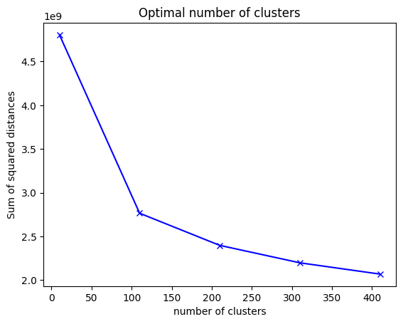

```python
BestCluster(vstack_descriptors_train24, arrange = (10, 411, 100))
```

#### *n_hist= 4, n_ori = 8*

```python
# 9s
n_hist = 4
n_ori = 8

descriptors_train48, descriptors_test48 = descriptors(image_dict_train,  image_dict_test, n_hist = n_hist, n_ori = n_ori)
vstack_descriptors_train48 = stack_descriptors(descriptors_train48)

print('Descriptors Train Shape: ', vstack_descriptors_train48.shape)
```

```
SIFT DESCRIPTORS
Descriptors Train Shape:  (227984, 128)
```

```
The range:  [ 10 110 210 310 410]
Number of clusters: | 10 | 110 | 210 | 310 | 410 |
```

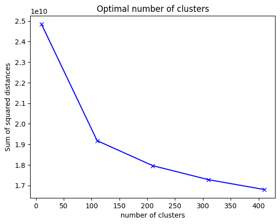

```python
BestCluster(vstack_descriptors_train48, arrange = (10, 411, 100))
```

#### *n_hist= 6, n_ori = 12*

```python
# 9s
n_hist = 6
n_ori = 12

descriptors_train612, descriptors_test612 = descriptors(image_dict_train,  image_dict_test, n_hist = n_hist, n_ori = n_ori)
vstack_descriptors_train612 = stack_descriptors(descriptors_train612)

print('Descriptors Train Shape: ', vstack_descriptors_train612.shape)
```

```
SIFT DESCRIPTORS
Descriptors Train Shape:  (227984, 432)
```

```
The range:  [ 10 110 210 310 410]
Number of clusters: | 10 | 110 | 210 | 310 | 410 |
```

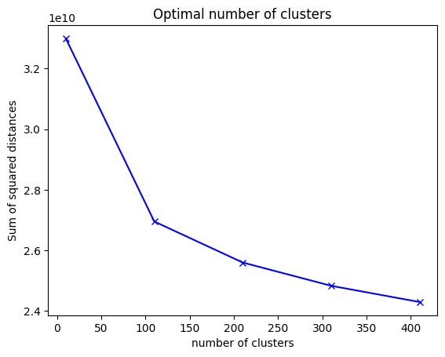

```python
BestCluster(vstack_descriptors_train612, arrange = (10, 411, 100))
```

## *Calculate the Descripts using SIFT and PCA*

#### *n_hist= 2, n_ori = 4*

```python
#6s
n_hist = 2
n_ori = 4

pca_descriptors_train24, pca_descriptors_test24 = pca_descriptors(image_dict_train, image_dict_test, n_hist = n_hist, n_ori = n_ori, n_pca = 8)
pca_vstack_descriptors_train24 = stack_descriptors(pca_descriptors_train24)

print('Descriptors Train Shape: ', pca_vstack_descriptors_train24.shape)
```

```
SIFT DESCRIPTORS - PCA
Descriptors Train Shape:  (227984, 8)
```

```
The range:  [ 10 110 210 310 410]
Number of clusters: | 10 | 110 | 210 | 310 | 410 |
```

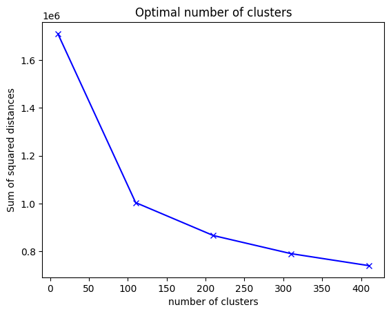

```python
BestCluster(pca_vstack_descriptors_train24, arrange = (10, 411, 100))
```

#### *n_hist= 4, n_ori = 8*

```python
#6s
n_hist = 4
n_ori = 8

pca_descriptors_train48, pca_descriptors_test48 = pca_descriptors(image_dict_train, image_dict_test, n_hist = n_hist, n_ori = n_ori, n_pca = 12)
pca_vstack_descriptors_train48 = stack_descriptors(pca_descriptors_train48)

print('Descriptors Train Shape: ', pca_vstack_descriptors_train48.shape)
```

```
SIFT DESCRIPTORS - PCA
Descriptors Train Shape:  (227984, 12)
```

```
The range:  [ 10 110 210 310 410]
Number of clusters: | 10 | 110 | 210 | 310 | 410 |
```

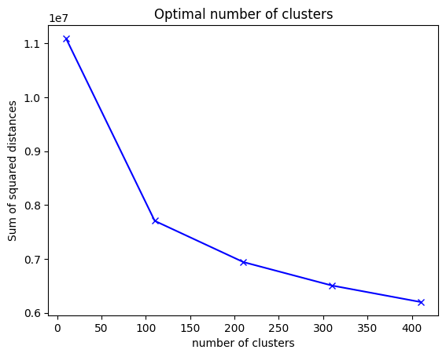

```python
BestCluster(pca_vstack_descriptors_train48, arrange = (10, 411, 100))
```

#### *n_hist= 6, n_ori = 12*

```python
#6s
n_hist = 6
n_ori = 12

pca_descriptors_train612, pca_descriptors_test612 = pca_descriptors(image_dict_train, image_dict_test, n_hist = n_hist, n_ori = n_ori, n_pca = 12)
pca_vstack_descriptors_train612 = stack_descriptors(pca_descriptors_train612)

print('Descriptors Train Shape: ', pca_vstack_descriptors_train612.shape)
```

```
SIFT DESCRIPTORS - PCA
Descriptors Train Shape:  (227984, 12)
```

```
The range:  [ 10 110 210 310 410]
Number of clusters: | 10 | 110 | 210 | 310 | 410 |
```

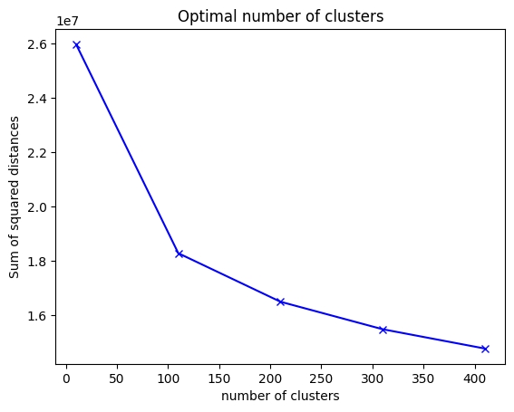

```python
BestCluster(pca_vstack_descriptors_train612, arrange = (10, 411, 100))
```

## *The features based on the optimal number of clusters.*

```python
IMAGE_COUNT_TRAIN = total_train
IMAGE_COUNT_TEST = total_test
```

```
Image Features Train Shape (1200, 50)
```

[figure not shown]

```
Image Features Test Shape (570, 50)
```

[figure not shown]

```python
# 1s
#

N_CLUSTERS = 50

kmeans = KMeans(n_clusters = N_CLUSTERS, n_init='auto', random_state=RANDOM_SEED).fit(vstack_descriptors_train24)

img_features_train50_24, label_trainl50_24 = ExtractFeatures(kmeans, descriptors_train24, IMAGE_COUNT_TRAIN, N_CLUSTERS)
img_features_test50_24, label_test50_24 = ExtractFeatures(kmeans, descriptors_test24, IMAGE_COUNT_TEST , N_CLUSTERS)

####### save
# np.save("/content/drive/MyDrive/Colab Notebooks/feat_train_50_2_4.npy", img_features_train50_24)
# np.save("/content/drive/MyDrive/Colab Notebooks/feat_test_50_2_4.npy", img_features_test50_24)

print('Image Features Train Shape', img_features_train50_24.shape)
plotHistogram(img_features_train50_24, N_CLUSTERS, 'Cluster 50 and n_hist=4, n_ori = 8')

print("")
print('Image Features Test Shape', img_features_test50_24.shape)
plotHistogram(img_features_test50_24, N_CLUSTERS, 'Cluster 50 and n_hist=4, n_ori = 8')
```

```
Image Features Train Shape (1200, 150)
```

[figure not shown]

```
Image Features Test Shape (570, 150)
```

[figure not shown]

```python
#1s

N_CLUSTERS = 150

kmeans = KMeans(n_clusters = N_CLUSTERS, n_init='auto', random_state=RANDOM_SEED).fit(vstack_descriptors_train24)

img_features_train150_24, label_train150_24 = ExtractFeatures(kmeans, descriptors_train24, IMAGE_COUNT_TRAIN, N_CLUSTERS)
img_features_test150_24, label_test150_24 = ExtractFeatures(kmeans, descriptors_test24, IMAGE_COUNT_TEST , N_CLUSTERS)

####### save
# np.save("/content/drive/MyDrive/Colab Notebooks/feat_train_150_2_4.npy", img_features_train150_24)
# np.save("/content/drive/MyDrive/Colab Notebooks/feat_test_150_2_4.npy", img_features_test150_24)

print('Image Features Train Shape', img_features_train150_24.shape)
plotHistogram(img_features_train150_24, N_CLUSTERS, 'Cluster 50 and n_hist=4, n_ori = 8')

print("")
print('Image Features Test Shape', img_features_test150_24.shape)
plotHistogram(img_features_test150_24, N_CLUSTERS, 'Cluster 50 and n_hist=4, n_ori = 8')
```

```
Image Features Train Shape (1200, 50)
```

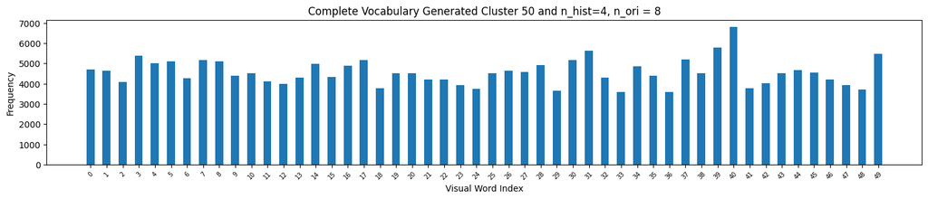

```
Image Features Test Shape (570, 50)
```

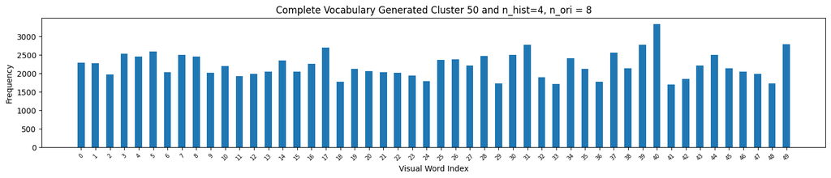

```python
# 1s
#

N_CLUSTERS = 50

kmeans = KMeans(n_clusters = N_CLUSTERS, n_init='auto', random_state=RANDOM_SEED).fit(vstack_descriptors_train48)

img_features_train50_48, label_train50_48 = ExtractFeatures(kmeans, descriptors_train48,  IMAGE_COUNT_TRAIN, N_CLUSTERS)
img_features_test50_48, label_test50_48  = ExtractFeatures(kmeans, descriptors_test48, IMAGE_COUNT_TEST , N_CLUSTERS)

####### save
# np.save("/content/drive/MyDrive/Colab Notebooks/feat_train_50_4_8.npy", img_features_train50_48)
# np.save("/content/drive/MyDrive/Colab Notebooks/feat_test_50_4_8.npy", img_features_test50_48)

print('Image Features Train Shape', img_features_train50_48.shape)
plotHistogram(img_features_train50_48, N_CLUSTERS, 'Cluster 50 and n_hist=4, n_ori = 8')

print("")
print('Image Features Test Shape', img_features_test50_48.shape)
plotHistogram(img_features_test50_48, N_CLUSTERS, 'Cluster 50 and n_hist=4, n_ori = 8')
```

```
Image Features Train Shape (1200, 150)
```

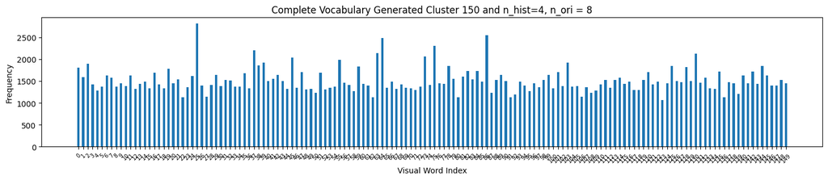

```
Image Features Test Shape (570, 150)
```

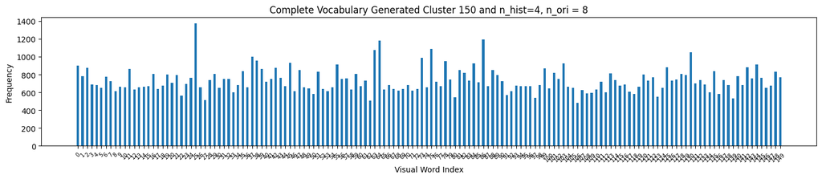

```python
# 3m22s
# 19s

N_CLUSTERS = 150

kmeans = KMeans(n_clusters = N_CLUSTERS, n_init='auto', random_state=RANDOM_SEED).fit(vstack_descriptors_train48)

img_features_train150_48, label_train150_48 = ExtractFeatures(kmeans, descriptors_train48, IMAGE_COUNT_TRAIN, N_CLUSTERS)
img_features_test150_48, label_test150_48  = ExtractFeatures(kmeans, descriptors_test48, IMAGE_COUNT_TEST , N_CLUSTERS)

####### save
# np.save("/content/drive/MyDrive/Colab Notebooks/feat_train_150_4_8.npy", img_features_train150_48)
# np.save("/content/drive/MyDrive/Colab Notebooks/feat_test_150_4_8.npy", img_features_test150_48)

print('Image Features Train Shape', img_features_train150_48.shape)
plotHistogram(img_features_train150_48, N_CLUSTERS, 'Cluster 150 and n_hist=4, n_ori = 8')

print("")
print('Image Features Test Shape', img_features_test150_48.shape)
plotHistogram(img_features_test150_48, N_CLUSTERS, 'Cluster 150 and n_hist=4, n_ori = 8')
```

```
Image Features Train Shape (1200, 50)
```

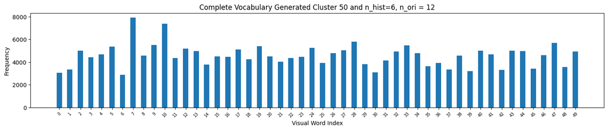

```
Image Features Test Shape (570, 50)
```

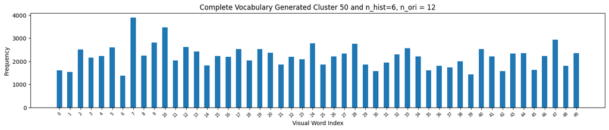

```python
# 3m22s
# 19s

N_CLUSTERS = 50

kmeans = KMeans(n_clusters = N_CLUSTERS, n_init='auto', random_state=RANDOM_SEED).fit(vstack_descriptors_train612)

img_features_train50_612, label_train50_612 = ExtractFeatures(kmeans, descriptors_train612, IMAGE_COUNT_TRAIN, N_CLUSTERS)
img_features_test50_612, label_test50_612  = ExtractFeatures(kmeans, descriptors_test612, IMAGE_COUNT_TEST , N_CLUSTERS)

####### save
# np.save("/content/drive/MyDrive/Colab Notebooks/feat_train_50_6_12.npy", img_features_train50_612)
# np.save("/content/drive/MyDrive/Colab Notebooks/feat_test_50_6_12.npy", img_features_test50_612)

print('Image Features Train Shape', img_features_train50_612.shape)
plotHistogram(img_features_train50_612, N_CLUSTERS, 'Cluster 50 and n_hist=6, n_ori = 12')

print("")
print('Image Features Test Shape', img_features_test50_612.shape)
plotHistogram(img_features_test50_612, N_CLUSTERS, 'Cluster 50 and n_hist=6, n_ori = 12')
```

```
Image Features Train Shape (1200, 150)
```

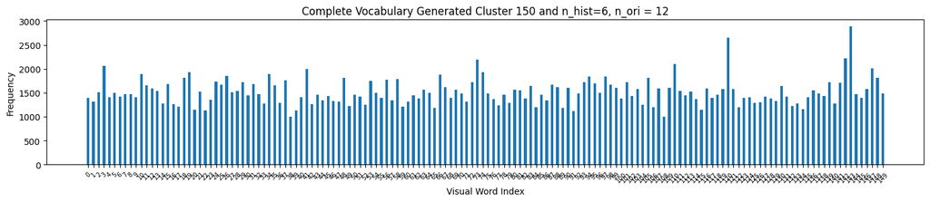

```
Image Features Test Shape (570, 150)
```

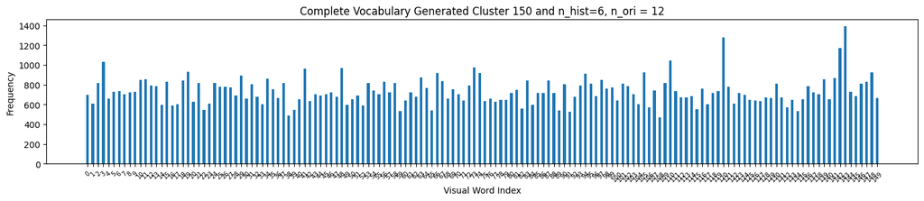

```python
# 3m22s
# 19s

N_CLUSTERS = 150

kmeans = KMeans(n_clusters = N_CLUSTERS, n_init='auto', random_state=RANDOM_SEED).fit(vstack_descriptors_train612)

img_features_train150_612, label_train150_612 = ExtractFeatures(kmeans, descriptors_train612, IMAGE_COUNT_TRAIN, N_CLUSTERS)
img_features_test150_612, label_test150_612  = ExtractFeatures(kmeans, descriptors_test612, IMAGE_COUNT_TEST , N_CLUSTERS)

####### save
# np.save("/content/drive/MyDrive/Colab Notebooks/feat_train_150_6_12.npy", img_features_train150_612)
# np.save("/content/drive/MyDrive/Colab Notebooks/feat_test_150_6_12.npy", img_features_test150_612)

print('Image Features Train Shape', img_features_train150_612.shape)
plotHistogram(img_features_train150_612, N_CLUSTERS, 'Cluster 150 and n_hist=6, n_ori = 12')

print("")
print('Image Features Test Shape', img_features_test150_612.shape)
plotHistogram(img_features_test150_612, N_CLUSTERS, 'Cluster 150 and n_hist=6, n_ori = 12')
```

## *The features based on the optimal number of clusters and PCA.*

```
Image Features Train Shape (1200, 50)
```

[figure not shown]

```
Image Features Test Shape (570, 50)
```

[figure not shown]

```python
N_CLUSTERS = 50

kmeans = KMeans(n_clusters = N_CLUSTERS, n_init='auto', random_state=RANDOM_SEED).fit(pca_vstack_descriptors_train24)

pca_img_features_train50_24, pca_labe_trainl50_24 = ExtractFeatures(kmeans, pca_descriptors_train24, IMAGE_COUNT_TRAIN, N_CLUSTERS)
pca_img_features_test50_24, pca_label_test50_24 = ExtractFeatures(kmeans, pca_descriptors_test24, IMAGE_COUNT_TEST , N_CLUSTERS)

####### save
# np.save("/content/drive/MyDrive/Colab Notebooks/pca_feat_train_50_2_4.npy", pca_img_features_train50_24)
# np.save("/content/drive/MyDrive/Colab Notebooks/pca_feat_test_50_2_4.npy", pca_img_features_test50_24)

print('Image Features Train Shape', pca_img_features_train50_24.shape)
plotHistogram(pca_img_features_train50_24, N_CLUSTERS, 'Cluster 50 and n_hist=4, n_ori = 8')

print("")
print('Image Features Test Shape', pca_img_features_test50_24.shape)
plotHistogram(pca_img_features_test50_24, N_CLUSTERS, 'Cluster 50 and n_hist=4, n_ori = 8')
```

```
Image Features Train Shape (1200, 150)
```

[figure not shown]

```
Image Features Test Shape (570, 150)
```

[figure not shown]

```python
N_CLUSTERS = 150

kmeans = KMeans(n_clusters = N_CLUSTERS, n_init='auto', random_state=RANDOM_SEED).fit(pca_vstack_descriptors_train24)

pca_img_features_train150_24, pca_label_train150_24 = ExtractFeatures(kmeans, pca_descriptors_train24, IMAGE_COUNT_TRAIN, N_CLUSTERS)
pca_img_features_test150_24, pca_label_test150_24 = ExtractFeatures(kmeans, pca_descriptors_test24, IMAGE_COUNT_TEST , N_CLUSTERS)

####### save
# np.save("/content/drive/MyDrive/Colab Notebooks/pca_feat_train_150_2_4.npy", pca_img_features_train150_24)
# np.save("/content/drive/MyDrive/Colab Notebooks/pca_feat_test_150_2_4.npy", pca_img_features_test150_24)

print('Image Features Train Shape', pca_img_features_train150_24.shape)
plotHistogram(pca_img_features_train150_24, N_CLUSTERS, 'Cluster 50 and n_hist=4, n_ori = 8')

print("")
print('Image Features Test Shape', pca_img_features_test150_24.shape)
plotHistogram(pca_img_features_test150_24, N_CLUSTERS, 'Cluster 50 and n_hist=4, n_ori = 8')
```

```
Image Features Train Shape (1200, 50)
```

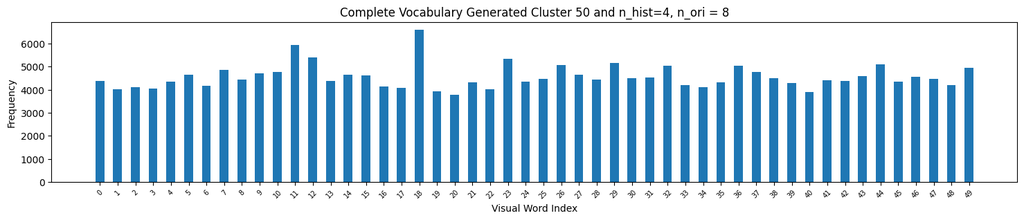

```
Image Features Test Shape (570, 50)
```

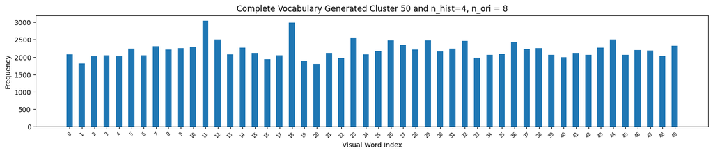

```python
N_CLUSTERS = 50

kmeans = KMeans(n_clusters = N_CLUSTERS, n_init='auto', random_state=RANDOM_SEED).fit(pca_vstack_descriptors_train48)

pca_img_features_train50_48, pca_label_train50_48 = ExtractFeatures(kmeans, pca_descriptors_train48,  IMAGE_COUNT_TRAIN, N_CLUSTERS)
pca_img_features_test50_48, pca_label_test50_48  = ExtractFeatures(kmeans, pca_descriptors_test48, IMAGE_COUNT_TEST , N_CLUSTERS)

####### save
# np.save("/content/drive/MyDrive/Colab Notebooks/pca_feat_train_50_4_8.npy", pca_img_features_train50_48)
# np.save("/content/drive/MyDrive/Colab Notebooks/pca_feat_test_50_4_8.npy", pca_img_features_test50_48)

print('Image Features Train Shape', pca_img_features_train50_48.shape)
plotHistogram(pca_img_features_train50_48, N_CLUSTERS, 'Cluster 50 and n_hist=4, n_ori = 8')

print("")
print('Image Features Test Shape', pca_img_features_test50_48.shape)
plotHistogram(pca_img_features_test50_48, N_CLUSTERS, 'Cluster 50 and n_hist=4, n_ori = 8')
```

```
Image Features Train Shape (1200, 150)
```

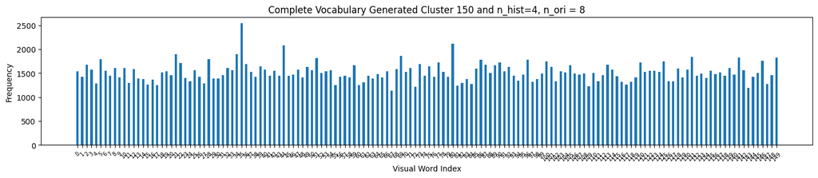

```
Image Features Test Shape (570, 150)
```

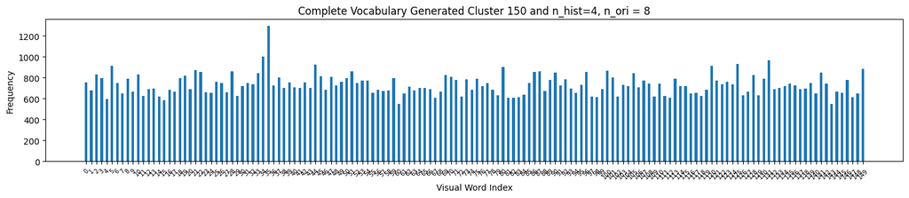

```python
N_CLUSTERS = 150

kmeans = KMeans(n_clusters = N_CLUSTERS, n_init='auto', random_state=RANDOM_SEED).fit(pca_vstack_descriptors_train48)

pca_img_features_train150_48, pca_label_train150_48 = ExtractFeatures(kmeans, pca_descriptors_train48, IMAGE_COUNT_TRAIN, N_CLUSTERS)
pca_img_features_test150_48, pca_label_test150_48  = ExtractFeatures(kmeans, pca_descriptors_test48, IMAGE_COUNT_TEST , N_CLUSTERS)

####### save
# np.save("/content/drive/MyDrive/Colab Notebooks/pca_feat_train_150_4_8.npy", pca_img_features_train150_48)
# np.save("/content/drive/MyDrive/Colab Notebooks/pca_feat_test_150_4_8.npy", pca_img_features_test150_48)

print('Image Features Train Shape', pca_img_features_train150_48.shape)
plotHistogram(pca_img_features_train150_48, N_CLUSTERS, 'Cluster 150 and n_hist=4, n_ori = 8')

print("")
print('Image Features Test Shape', pca_img_features_test150_48.shape)
plotHistogram(pca_img_features_test150_48, N_CLUSTERS, 'Cluster 150 and n_hist=4, n_ori = 8')
```

```
Image Features Train Shape (1200, 50)
```

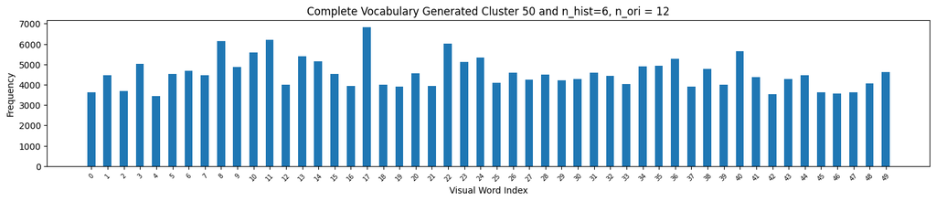

```
Image Features Test Shape (570, 50)
```

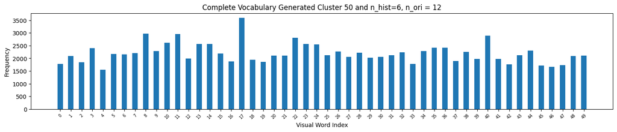

```python
N_CLUSTERS = 50

kmeans = KMeans(n_clusters = N_CLUSTERS, n_init='auto', random_state=RANDOM_SEED).fit(pca_vstack_descriptors_train612)

pca_img_features_train50_612, pca_label_train50_612 = ExtractFeatures(kmeans, pca_descriptors_train612, IMAGE_COUNT_TRAIN, N_CLUSTERS)
pca_img_features_test50_612, pca_label_test50_612  = ExtractFeatures(kmeans, pca_descriptors_test612, IMAGE_COUNT_TEST , N_CLUSTERS)

####### save
# np.save("/content/drive/MyDrive/Colab Notebooks/pca_feat_train_50_6_12.npy", pca_img_features_train50_612)
# np.save("/content/drive/MyDrive/Colab Notebooks/pca_feat_test_50_6_12.npy", pca_img_features_test50_612)

print('Image Features Train Shape', pca_img_features_train50_612.shape)
plotHistogram(pca_img_features_train50_612, N_CLUSTERS, 'Cluster 50 and n_hist=6, n_ori = 12')

print("")
print('Image Features Test Shape', pca_img_features_test50_612.shape)
plotHistogram(pca_img_features_test50_612, N_CLUSTERS, 'Cluster 50 and n_hist=6, n_ori = 12')
```

```
Image Features Train Shape (1200, 150)
```

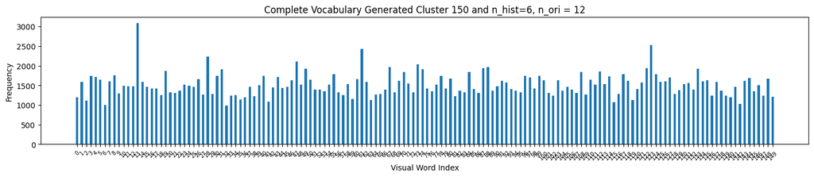

```
Image Features Test Shape (570, 150)
```

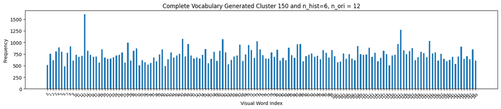

```python
N_CLUSTERS = 150

kmeans = KMeans(n_clusters = N_CLUSTERS, n_init='auto', random_state=RANDOM_SEED).fit(pca_vstack_descriptors_train612)

pca_img_features_train150_612, pca_label_train150_612 = ExtractFeatures(kmeans, pca_descriptors_train612, IMAGE_COUNT_TRAIN, N_CLUSTERS)
pca_img_features_test150_612, pca_label_test150_612  = ExtractFeatures(kmeans, pca_descriptors_test612, IMAGE_COUNT_TEST , N_CLUSTERS)

####### save
# np.save("/content/drive/MyDrive/Colab Notebooks/pca_feat_train_150_6_12.npy", pca_img_features_train150_612)
# np.save("/content/drive/MyDrive/Colab Notebooks/pca_feat_test_150_6_12.npy", pca_img_features_test150_612)

print('Image Features Train Shape', pca_img_features_train150_612.shape)
plotHistogram(pca_img_features_train150_612, N_CLUSTERS, 'Cluster 150 and n_hist=6, n_ori = 12')

print("")
print('Image Features Test Shape', pca_img_features_test150_612.shape)
plotHistogram(pca_img_features_test150_612, N_CLUSTERS, 'Cluster 150 and n_hist=6, n_ori = 12')
```